# Case_Study_1

Team Project - Babatunde John Olanipekun, Yvan Sojdehei and Mingyang Nick YU

9/30/2020

## Beer and Breweries Exploration

Introduction: This is an exploratory data analysis for the data set between Beers.csv and Breweries.csv for CEO and CFO of Budweiser

### Loading the datasets

Doing intial inspection of data through various methods below.

```r
# dataset should be in the same folder of this RMD file
Beers = read.csv("/Users/mingyang/Desktop/SMU/DoingDS_Fall2020/MSDS6306-Case-Study1/Beers.csv",header = TRUE) #loading beers dataset
Breweries = read.csv("/Users/mingyang/Desktop/SMU/DoingDS_Fall2020/MSDS6306-Case-Study1/Breweries.csv",header = TRUE) #loading breweries dataset
#below this line is for self analyzation
#summary(Beers)
#str(Beers)
##Beers$IBU
#summary(Breweries)
#str(Breweries)
#Above this line is for self analyzing can be deleted later
#Turn Breweries State column into a factor
Breweries$State = as.factor(Breweries$State)
```

### How many breweries are present in each state?

- As we can see by the plot below, each state’s breweries count is displayed in a bar chart
- To make it easier to see which state has the most breweries, we assorted the breweries count by descending order

```r
library(tidyverse)
```

```r
library(ggplot2)
num_Breweries_by_state = Breweries %>% group_by(State) %>%
  summarise(count=n())
num_Breweries_by_state
```

```
## # A tibble: 51 x 2
##    State count
##    <fct> <int>
##  1 " AK"     7
##  2 " AL"     3
##  3 " AR"     2
##  4 " AZ"    11
##  5 " CA"    39
##  6 " CO"    47
##  7 " CT"     8
##  8 " DC"     1
##  9 " DE"     2
## 10 " FL"    15
## # … with 41 more rows
```

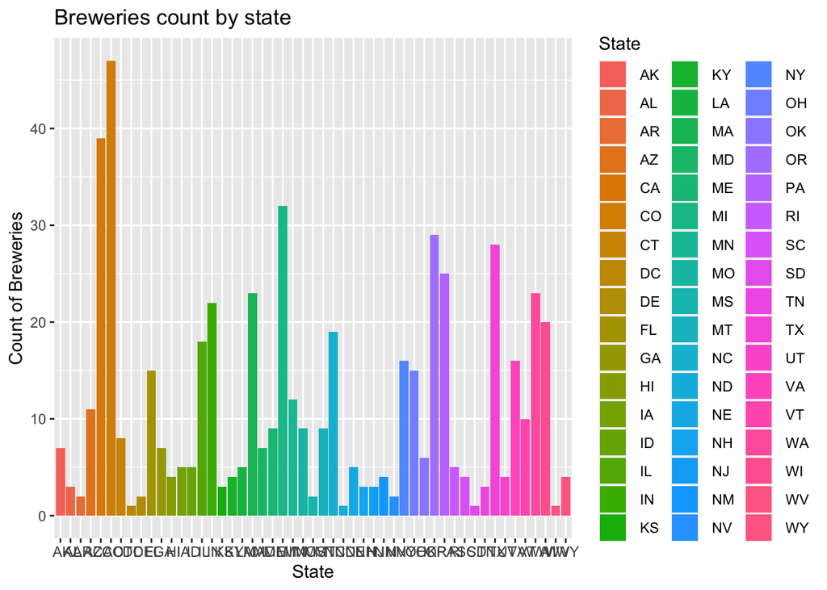

```r
#As we can see the number of breweries per state is in the list below, to see this better we will use a plot to show results
ggplot(data=num_Breweries_by_state)+
  geom_bar(mapping=aes(x=State,y=count,fill=State),stat="identity") +
  ggtitle("Breweries count by state")+xlab("State")+ylab("Count of Breweries")
```

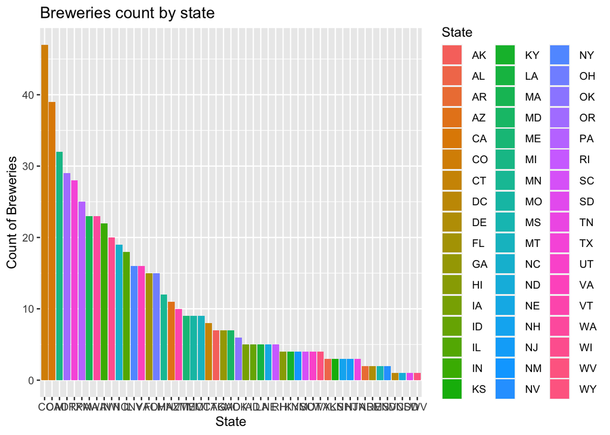

```r
#To see this by descend of count
ggplot(data=num_Breweries_by_state)+
  geom_bar(mapping=aes(x=reorder(State,-count),y=count,fill=State),stat="identity") +
  ggtitle("Breweries count by state")+xlab("State")+ylab("Count of Breweries")
```

### Merge beer data with the breweries data. Print the first 6 observations and the last six observations to check the merged file.

```r
Beers = Beers %>% rename(Brew_ID= Brewery_id)
Beers.with.Breweries = left_join(Beers,Breweries, by = "Brew_ID")
Beers.with.Breweries = Beers.with.Breweries %>% rename(Beer_Name= Name.x)
Beers.with.Breweries = Beers.with.Breweries %>% rename(Brew_Name= Name.y)
head(Beers.with.Breweries,6)
```

```
##             Beer_Name Beer_ID   ABV IBU Brew_ID                          Style
## 1            Pub Beer    1436 0.050  NA     409            American Pale Lager
## 2         Devil's Cup    2265 0.066  NA     178        American Pale Ale (APA)
## 3 Rise of the Phoenix    2264 0.071  NA     178                   American IPA
## 4            Sinister    2263 0.090  NA     178 American Double / Imperial IPA
## 5       Sex and Candy    2262 0.075  NA     178                   American IPA
## 6        Black Exodus    2261 0.077  NA     178                  Oatmeal Stout
##   Ounces                 Brew_Name City State
## 1     12 10 Barrel Brewing Company Bend    OR
## 2     12       18th Street Brewery Gary    IN
## 3     12       18th Street Brewery Gary    IN
## 4     12       18th Street Brewery Gary    IN
## 5     12       18th Street Brewery Gary    IN
## 6     12       18th Street Brewery Gary    IN
```

### Address the missing values in each column

- There are 62 missing values on ABV column, and there are 1005 missing values on IBU column
- Since 1005/2410 is too big of a percentage of missing value for column IBU, I decided to use Predictive mean matching method(widely used statistical imputation method for missing values, first proposed by Donald B. Rubin in 1986 and R. J. A. Little in 1988) to fill the missing data.
- After generating and filling in the missing data, through density plot below, we can see the generated filled in value matches the original density plot. Thus minimize any bias from the researcher of arbitrarily filling in value or overeasily using the overall mean for all missing value

```r
summary(Beers.with.Breweries)
```

```
##   Beer_Name            Beer_ID            ABV               IBU
##  Length:2410        Min.   :   1.0   Min.   :0.00100   Min.   :  4.00
##  Class :character   1st Qu.: 808.2   1st Qu.:0.05000   1st Qu.: 21.00
##  Mode  :character   Median :1453.5   Median :0.05600   Median : 35.00
##                     Mean   :1431.1   Mean   :0.05977   Mean   : 42.71
##                     3rd Qu.:2075.8   3rd Qu.:0.06700   3rd Qu.: 64.00
##                     Max.   :2692.0   Max.   :0.12800   Max.   :138.00
##                                      NA's   :62        NA's   :1005
##     Brew_ID         Style               Ounces       Brew_Name
##  Min.   :  1.0   Length:2410        Min.   : 8.40   Length:2410
##  1st Qu.: 94.0   Class :character   1st Qu.:12.00   Class :character
##  Median :206.0   Mode  :character   Median :12.00   Mode  :character
##  Mean   :232.7                      Mean   :13.59
##  3rd Qu.:367.0                      3rd Qu.:16.00
##  Max.   :558.0                      Max.   :32.00
##
##      City               State
##  Length:2410         CO    : 265
##  Class :character    CA    : 183
##  Mode  :character    MI    : 162
##                      IN    : 139
##                      TX    : 130
##                      OR    : 125
##                     (Other):1406
```

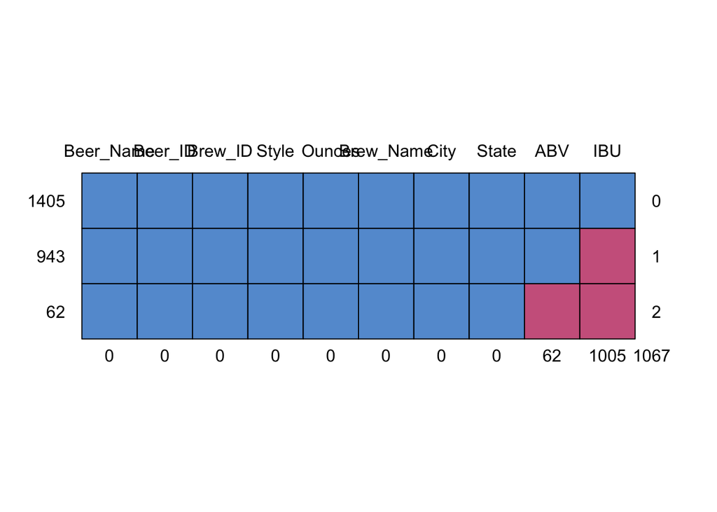

```
##      Beer_Name Beer_ID Brew_ID Style Ounces Brew_Name City State ABV  IBU
## 1405         1       1       1     1      1         1    1     1   1    1    0
## 943          1       1       1     1      1         1    1     1   1    0    1
## 62           1       1       1     1      1         1    1     1   0    0    2
##              0       0       0     0      0         0    0     0  62 1005 1067
```

```r
library(mice) #Load mice library to analyze the pattern of missing data
md.pattern(Beers.with.Breweries)
```

```r
# Since there is large amont of data missing in IBM column
#Try to impute the missing data with Predictive mean Matching method
tempData <- mice(Beers.with.Breweries,m=5,maxit=50,meth='pmm',seed=20)
```

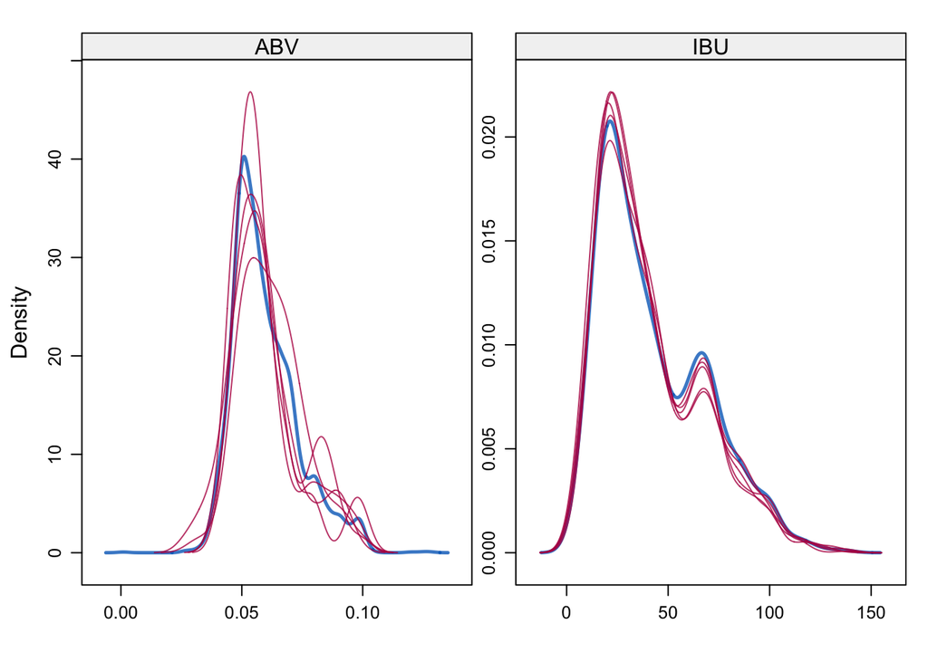

```r
#summary(tempData)
# completed dataset after adding in generated predictive values
completedData <- complete(tempData,1)
#head(completedData)
# Density plot original vs imputed dataset
densityplot(tempData)
```

```r
#Note: idea used above to impute data is from link below:
#https://datascienceplus.com/imputing-missing-data-with-r-mice-package/
```

### Compute the median alcohol content and international bitterness unit for each state. Plot a bar chart to compare

- First plotted Median alcohol content by state, one with modified data set, and the other one with non-modified data set
- Then plotted Median international bitterness unit for each state, both on the modified data set and non-modified
- We can see between the modified data and non-modified data provides very different answers. If possible, going back to try to complete the missing data will make the graphics more accurate. But this is a random estimate of the actual value

```r
#Compute and display Median of ABV and IBU by state:
median = completedData %>% group_by(State) %>%
  summarize(median_ABV=median(ABV),median_IBU=median(IBU))
median
```

```
## # A tibble: 51 x 3
##    State median_ABV median_IBU
##    <fct>      <dbl>      <dbl>
##  1 " AK"     0.056        35
##  2 " AL"     0.06         39.5
##  3 " AR"     0.052        72
##  4 " AZ"     0.055        28
##  5 " CA"     0.058        36
##  6 " CO"     0.061        35
##  7 " CT"     0.06         32
##  8 " DC"     0.0625       75
##  9 " DE"     0.0705       52
## 10 " FL"     0.0555       36.5
## # … with 41 more rows
```

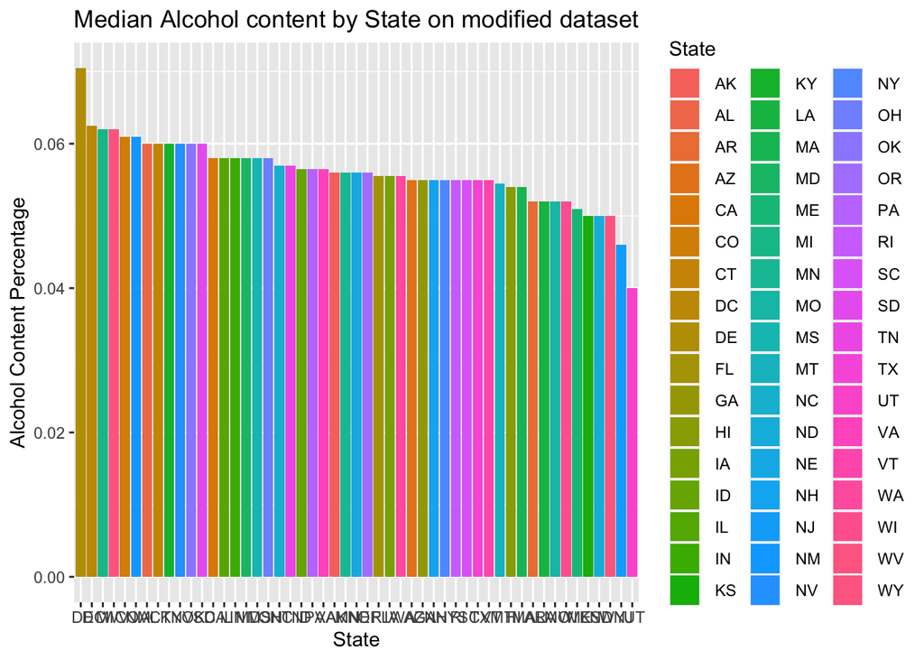

```r
#Draw Bar Charts to compare
#First plot median of alcohol content using modified data
median %>% ggplot()+
  geom_bar(mapping=aes(x=reorder(State,-median_ABV),y=median_ABV,fill=State),stat="identity") +
  ggtitle("Median Alcohol content by State on modified dataset")+xlab("State")+ylab("Alcohol Content Percentage")
```

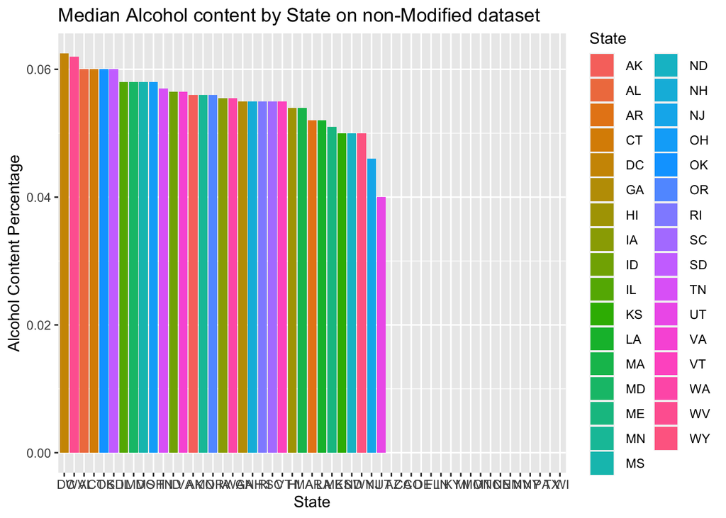

```r
#Below is result of using complete data set with missing data to plot median of alcohol content
Beers.with.Breweries %>% group_by(State) %>%
  summarize(median_ABV=median(ABV),median_IBU=median(IBU))%>% ggplot()+
  geom_bar(mapping=aes(x=reorder(State,-median_ABV),y=median_ABV,fill=State),stat="identity")+
  ggtitle("Median Alcohol content by State on non-Modified dataset")+xlab("State")+ylab("Alcohol Content Percentage")
```

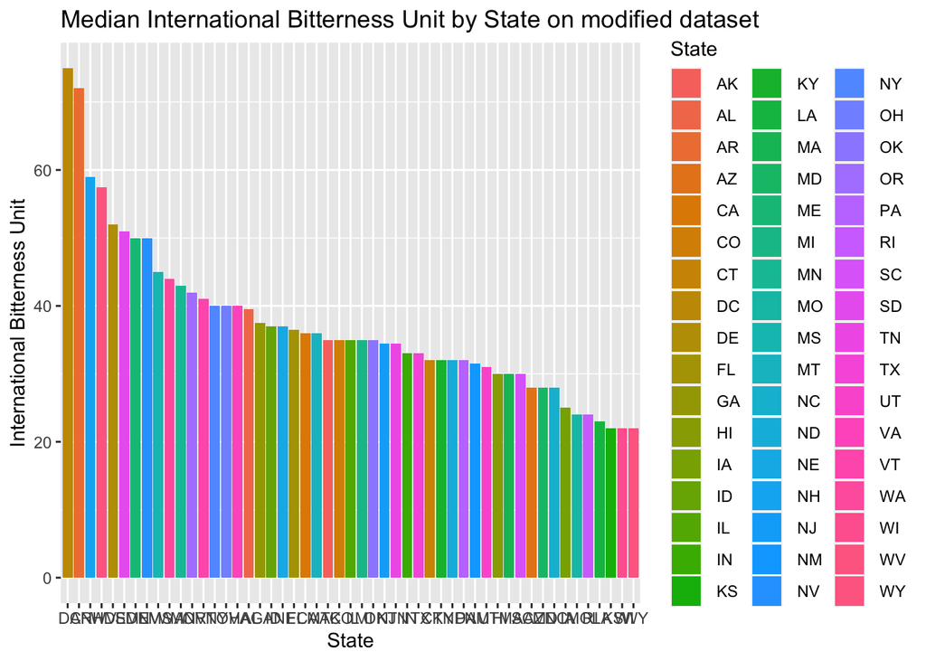

```r
#Below is result of plotting median international bitterness unit for each state on modified data set
median %>% ggplot()+
  geom_bar(mapping=aes(x=reorder(State,-median_IBU),y=median_IBU,fill=State),stat="identity") +
  ggtitle("Median International Bitterness Unit by State on modified dataset")+xlab("State")+ylab("International Bitterness Unit")
```

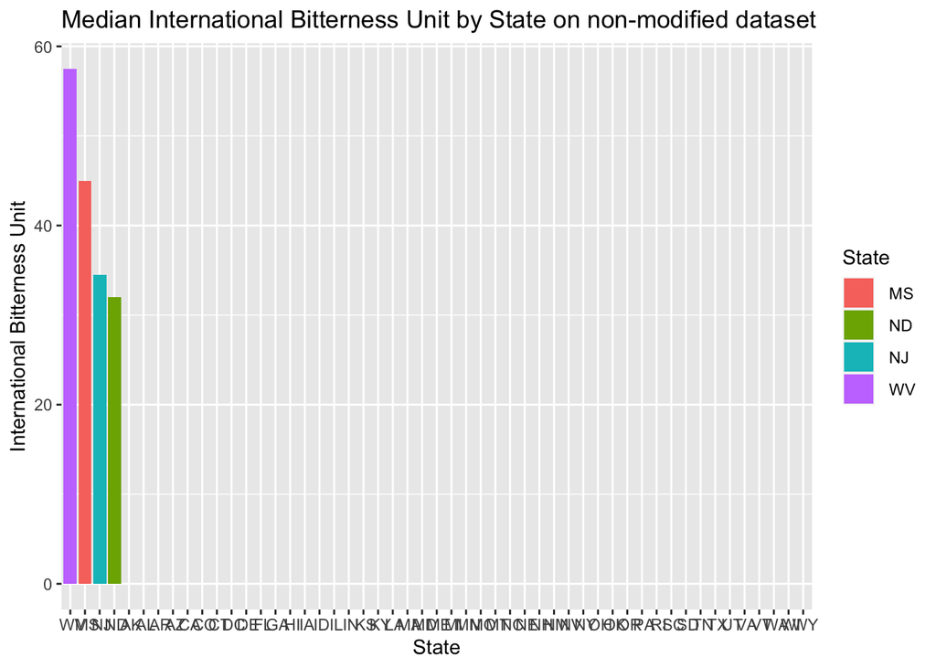

```r
#Below is result of using complete data set with missing data to plot median of alcohol content
Beers.with.Breweries %>% group_by(State) %>%
  summarize(median_ABV=median(ABV),median_IBU=median(IBU))%>% ggplot()+
  geom_bar(mapping=aes(x=reorder(State,-median_IBU),y=median_IBU,fill=State),stat="identity") +
  ggtitle("Median International Bitterness Unit by State on non-modified dataset")+xlab("State")+ylab("International Bitterness Unit")
```

### Exploring which state has the maximum alcoholic (ABV) beer and which state has the most bitter (IBU) beer

- As we can see below, Colorado ‘CO’ has the maximum alcoholic(ABV) beer, it is (0.128)
- This above result remain unchanged with the original data set
- As we can see, Oregon and Michigan have the most bitter beer
- Only Oregon has the most bitter beer in the unchanged data set. It means the Michigan bee bitterness value was imputed

```r
# Discover which state has the maximum alcoholic beer
head(completedData %>%
  arrange(desc(ABV)) %>%
  select(State,ABV,Beer_Name))
```

```
##   State   ABV                                            Beer_Name
## 1    CO 0.128 Lee Hill Series Vol. 5 - Belgian Style Quadrupel Ale
## 2    KY 0.125                                       London Balling
## 3    IN 0.120                                                 Csar
## 4    CO 0.104     Lee Hill Series Vol. 4 - Manhattan Style Rye Ale
## 5    NY 0.100                                               4Beans
## 6    CA 0.099                                        Lower De Boom
```

```r
# Discover with un-changed data set
head(Beers.with.Breweries %>%
  arrange(desc(ABV)) %>%
  select(State,ABV,Beer_Name))
```

```
##   State   ABV                                            Beer_Name
## 1    CO 0.128 Lee Hill Series Vol. 5 - Belgian Style Quadrupel Ale
## 2    KY 0.125                                       London Balling
## 3    IN 0.120                                                 Csar
## 4    CO 0.104     Lee Hill Series Vol. 4 - Manhattan Style Rye Ale
## 5    NY 0.100                                               4Beans
## 6    CA 0.099                                        Lower De Boom
```

```r
# Discover which state has the most bitter (IBU) beer
head(completedData %>%
  arrange(desc(IBU)) %>%
  select(State,IBU,Beer_Name))
```

```
##   State IBU                 Beer_Name
## 1    OR 138 Bitter Bitch Imperial IPA
## 2    MI 138                    Zaison
## 3    MI 138       Lemon Shandy Tripel
## 4    VA 135        Troopers Alley IPA
## 5    MI 130      Escoffier Bretta Ale
## 6    MA 130             Dead-Eye DIPA
```

```r
# Discover with un-changed data set
head(Beers.with.Breweries %>%
  arrange(desc(IBU)) %>%
  select(State,IBU,Beer_Name))
```

```
##   State IBU                       Beer_Name
## 1    OR 138       Bitter Bitch Imperial IPA
## 2    VA 135              Troopers Alley IPA
## 3    MA 130                   Dead-Eye DIPA
## 4    OH 126 Bay of Bengal Double IPA (2014)
## 5    MN 120                    Abrasive Ale
## 6    VT 120                    Heady Topper
```

### Comment on the summary statistics and distribution of the ABV variable.

- **For the adjusted data set, we have**
- Minimum ABV value: 0.001 (minimum value of the group, CEO and CFO might be interested)
- First quartile ABV: 0.05
- Median of ABV: 0.056 (center among the entire group, CEO and CFO might be interested)
- Mean of ABV: 0.05975 (Average of the entire group, CEO and CFO might be interested)
- Third Quartile ABV: 0.067
- Maximum ABV: 0.128 (maximum value of the group, CEO and CFO might be interested)
- **Comparing the adjusted Data and Unadjusted data, Statistics doesn’t change much at all since it is imputed by Predictive mean matching method**

```r
# Summary of adjusted Data
summary(completedData)
```

```
##   Beer_Name            Beer_ID            ABV               IBU
##  Length:2410        Min.   :   1.0   Min.   :0.00100   Min.   :  4.00
##  Class :character   1st Qu.: 808.2   1st Qu.:0.05000   1st Qu.: 21.00
##  Mode  :character   Median :1453.5   Median :0.05600   Median : 35.00
##                     Mean   :1431.1   Mean   :0.05975   Mean   : 41.99
##                     3rd Qu.:2075.8   3rd Qu.:0.06700   3rd Qu.: 61.00
##                     Max.   :2692.0   Max.   :0.12800   Max.   :138.00
##
##     Brew_ID         Style               Ounces       Brew_Name
##  Min.   :  1.0   Length:2410        Min.   : 8.40   Length:2410
##  1st Qu.: 94.0   Class :character   1st Qu.:12.00   Class :character
##  Median :206.0   Mode  :character   Median :12.00   Mode  :character
##  Mean   :232.7                      Mean   :13.59
##  3rd Qu.:367.0                      3rd Qu.:16.00
##  Max.   :558.0                      Max.   :32.00
##
##      City               State
##  Length:2410         CO    : 265
##  Class :character    CA    : 183
##  Mode  :character    MI    : 162
##                      IN    : 139
##                      TX    : 130
##                      OR    : 125
##                     (Other):1406
```

```r
# Summary of unadjusted Data
summary(Beers.with.Breweries)
```

```
##   Beer_Name            Beer_ID            ABV               IBU
##  Length:2410        Min.   :   1.0   Min.   :0.00100   Min.   :  4.00
##  Class :character   1st Qu.: 808.2   1st Qu.:0.05000   1st Qu.: 21.00
##  Mode  :character   Median :1453.5   Median :0.05600   Median : 35.00
##                     Mean   :1431.1   Mean   :0.05977   Mean   : 42.71
##                     3rd Qu.:2075.8   3rd Qu.:0.06700   3rd Qu.: 64.00
##                     Max.   :2692.0   Max.   :0.12800   Max.   :138.00
##                                      NA's   :62        NA's   :1005
##     Brew_ID         Style               Ounces       Brew_Name
##  Min.   :  1.0   Length:2410        Min.   : 8.40   Length:2410
##  1st Qu.: 94.0   Class :character   1st Qu.:12.00   Class :character
##  Median :206.0   Mode  :character   Median :12.00   Mode  :character
##  Mean   :232.7                      Mean   :13.59
##  3rd Qu.:367.0                      3rd Qu.:16.00
##  Max.   :558.0                      Max.   :32.00
##
##      City               State
##  Length:2410         CO    : 265
##  Class :character    CA    : 183
##  Mode  :character    MI    : 162
##                      IN    : 139
##                      TX    : 130
##                      OR    : 125
##                     (Other):1406
```

### Is there an apparent relationship between the bitterness of the beer and its alcoholic content?

- **We can see from the scatter plot, there seem to be some sort of relationship between the two**
- As ABV value increases, IBU seem to also increase
- **This relationship seem to persist when we compare to the unmodified data**

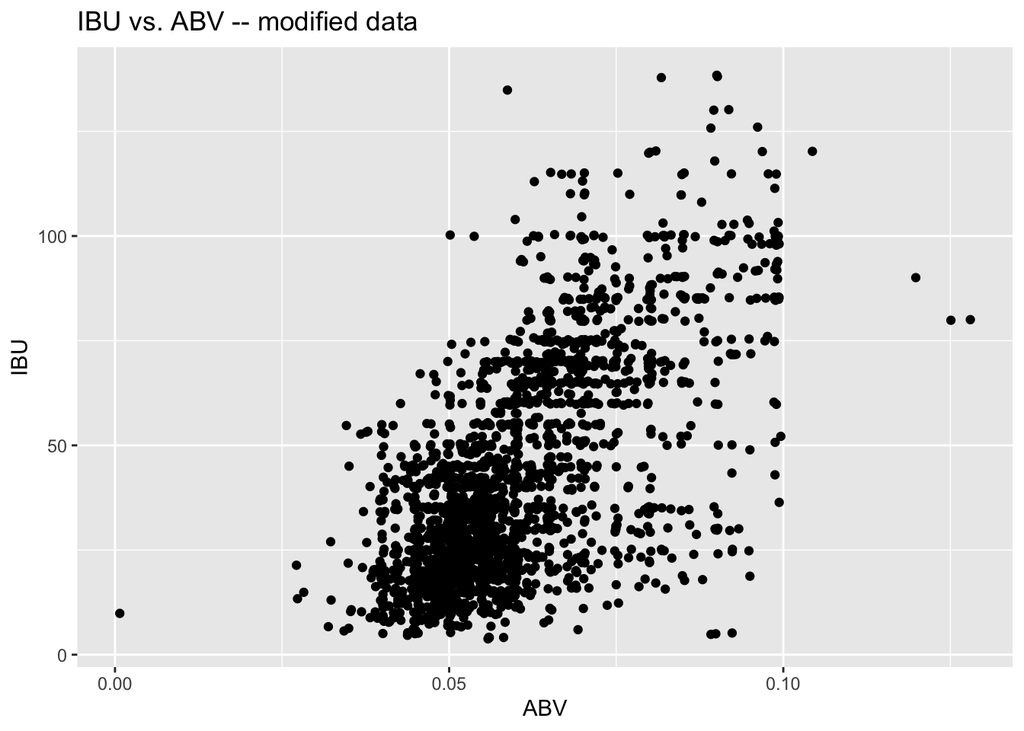

```r
#first explore modified data
completedData %>% select(ABV, IBU, State) %>%
  ggplot(aes(x=ABV,y=IBU)) +
  geom_point(position="jitter") +ggtitle("IBU vs. ABV -- modified data")
```

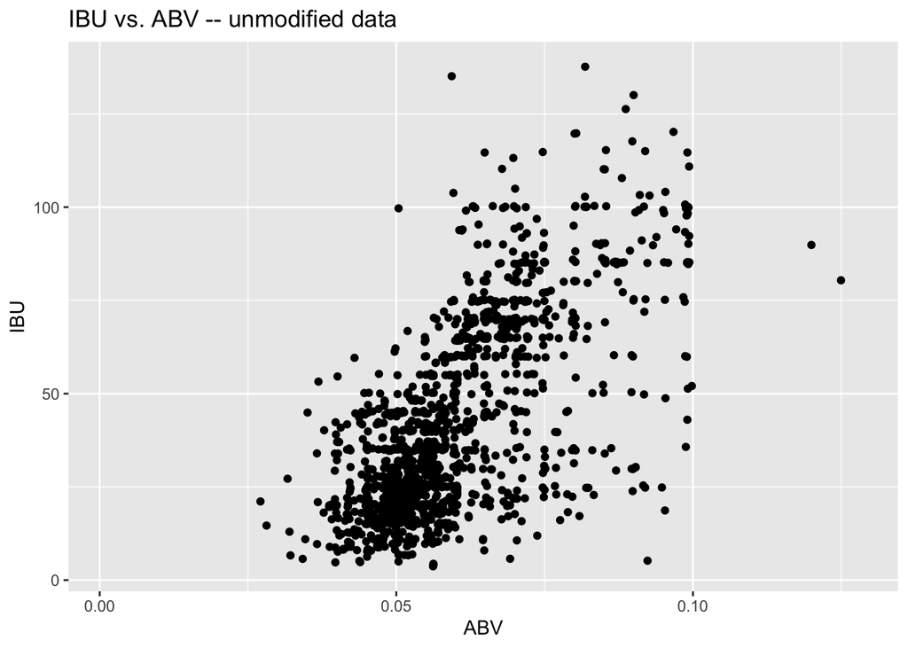

```r
#next explore unmodified data
Beers.with.Breweries %>% select(ABV, IBU, State) %>%
  ggplot(aes(x=ABV,y=IBU)) +
  geom_point(position="jitter") +ggtitle("IBU vs. ABV -- unmodified data")
```